# A3

```python
import os
import pandas as pd
import matplotlib.pyplot as plt
from mpl_toolkits.mplot3d import Axes3D
import numpy as np
import seaborn as sns
import requests
from sklearn import neighbors
from pylab import rcParams
from sklearn import preprocessing
from sklearn.model_selection import train_test_split
from sklearn.feature_selection import SelectKBest
from sklearn.neighbors import KNeighborsClassifier
from sklearn.tree import DecisionTreeClassifier
from sklearn.naive_bayes import GaussianNB
from sklearn.cluster import KMeans
from collections import defaultdict
from sklearn.metrics.pairwise import euclidean_distances
from sklearn.decomposition import PCA

%matplotlib inline
plt.style.use("ggplot")
sns.set_palette("muted")
rcParams["figure.figsize"] = 15, 10
rcParams["font.size"] = 20
```

## Task 2 - BUILD SUPERVISED LEARNING MODELS

In this task, we will solve a classification problem that is based on the happiness data we dealt with in the previous task: We have seen the relationship between the subjective happiness and other features of citizens of different countries in the world. In the era of globalization, many people have unprecedented freedom to move across countries. Just like the variety of economical, political, and environmental reasons for people to be happy/unhappy, people decide to leave their home country for other countries for different motives.

This is a typical binary classification problem. We label a country with positive net migration class 1 and a country with negative migration class 0.

### Integration

We have two data sources: the *cleaned.csv* we acquired previously, containing features around happiness score across countries, and World Bank Net Migration indicator.

```python
DATA_FILE = "cleaned.csv"
if not os.path.isfile(DATA_FILE):
    raise Exception("Input file {} does not exist.".format(DATA_FILE))

data = pd.read_csv(DATA_FILE).drop(columns=["Unnamed: 0"])
```

```python
def get_all_country_data_for_years(indicator_code, start_year, end_year, per_page = 5000):
    TEMPLATE = "https://api.worldbank.org/v2/country/all/indicator/%s?format=json&date=%s:%s&per_page=%s"
    URL = TEMPLATE % (indicator_code, start_year, end_year, per_page)
    result = json.loads(requests.get(URL).content)
    if result[0]["per_page"] < result[0]["total"]:
        URL = TEMPLATE % (indicator_code, start_year,
                          end_year, result[0]["total"])
        result = json.loads(requests.get(URL).content)
    return result
start_year, end_year = min(data["year"]), max(data["year"])
net_migration = pd.DataFrame.from_dict(get_all_country_data_for_years("SM.POP.NETM", start_year, end_year)[1])[["country", "date", "value"]].dropna(axis=0)
net_migration["country"] = net_migration["country"].apply(lambda x: x['value'])
net_migration["date"] = net_migration["date"].astype(int)
net_migration["value"] = net_migration["value"].apply(lambda x: 1 if x > 0 else 0) # we only care if it's immigration country or emigration country, not the actual number
net_migration.rename(
        columns={"date" : "year", "value": "migration_class"}, inplace=True)
net_migration
```

|  | country | year | migration_class |
| --- | --- | --- | --- |
| 1 | Arab World | 2017 | 0 |
| 6 | Arab World | 2012 | 1 |
| 11 | Arab World | 2007 | 1 |
| 15 | Caribbean small states | 2017 | 0 |
| 20 | Caribbean small states | 2012 | 0 |
| ... | ... | ... | ... |
| 3674 | Zambia | 2012 | 0 |
| 3679 | Zambia | 2007 | 0 |
| 3683 | Zimbabwe | 2017 | 0 |
| 3688 | Zimbabwe | 2012 | 0 |
| 3693 | Zimbabwe | 2007 | 0 |

720 rows × 3 columns

We have used Bing Map API in A2 to consolidate the country names. The API calling is omitted here. Instead, we use the result mapping directly to update the indicator country names:

```python
country_name_mapping = {
    "Iran, Islamic Rep.": "Iran",
    "Syrian Arab Republic": "Syria",
    "Congo, Rep.": "Congo (Brazzaville)",
    "North Macedonia": "Macedonia",
    "Kyrgyz Republic": "Kyrgyzstan",
    "Russian Federation": "Russia",
    "Gambia, The": "Gambia",
    "Yemen, Rep.": "Yemen",
    "Eswatini": "Swaziland",
    "Congo, Dem. Rep.": "Congo (Kinshasa)",
    "Korea, Rep.": "South Korea",
    "Slovak Republic": "Slovakia",
    "Hong Kong SAR, China": "Hong Kong S.A.R. of China",
    "Lao PDR": "Laos",
    "Cote d'Ivoire": "Ivory Coast",
    "West Bank and Gaza": "Palestinian Territories"
}
net_migration["country"] = net_migration["country"].apply(lambda n : country_name_mapping[n] if n in country_name_mapping else n)
```

Now we integrate the two data sources. We have done data cleaning in previous task, so now we have pretty dense data. We fill the sparse NaNs with column means.

```python
data = data.merge(net_migration, on=[
                  "country", "year"], how="left", validate="one_to_one").dropna(axis=0, subset=["migration_class"])
data["migration_class"] = data["migration_class"].astype(int)
data.drop(columns=["country","year"], inplace=True)

data = data.fillna(data.mean())
data
```

|  | happiness | log_gdp_pc | social_support | health | freedom | generosity | perception_corruption | p_affect | n_affect | gov_confidence | ... | deliver | gini_2010_2017 | gini_gallup | population | urban_pop_percent | unemployment | gov_edu_vs_gdp | forest_percent | trusted_wvs | migration_class |
| --- | --- | --- | --- | --- | --- | --- | --- | --- | --- | --- | --- | --- | --- | --- | --- | --- | --- | --- | --- | --- | --- |
| 4 | 3.782938 | 7.480296 | 0.520637 | 52.240002 | 0.530935 | 0.246943 | 0.775620 | 0.710385 | 0.267919 | 0.435440 | ... | -1.404078 | 0.386174 | 0.344540 | 31161376.0 | 24.160 | 11.508 | 2.604200 | 2.067825 | 0.248922 | 1 |
| 9 | 2.661718 | 7.472197 | 0.490880 | 52.799999 | 0.427011 | -0.110382 | 0.954393 | 0.496349 | 0.371326 | 0.261179 | ... | -1.440218 | 0.386174 | 0.286599 | 36296400.0 | 25.250 | 11.184 | 4.058870 | 30.077052 | 0.248922 | 0 |
| 11 | 4.634252 | 9.042030 | 0.821372 | 65.800003 | 0.528605 | -0.009072 | 0.874700 | 0.552678 | 0.246335 | 0.300681 | ... | -0.420024 | 0.303250 | 0.450304 | 2970017.0 | 48.902 | 15.966 | 3.275930 | 28.465694 | 0.237622 | 0 |
| 15 | 5.510124 | 9.246630 | 0.784502 | 66.959999 | 0.601512 | -0.169205 | 0.847675 | 0.606636 | 0.271393 | 0.364894 | ... | -0.328862 | 0.303250 | 0.568153 | 2900401.0 | 54.330 | 13.376 | 4.243697 | 28.262044 | 0.237622 | 0 |
| 20 | 4.639548 | 9.376133 | 0.637698 | 68.400002 | 0.749611 | -0.029357 | 0.876135 | 0.669241 | 0.333884 | 0.457738 | ... | -0.128311 | 0.303250 | 0.410488 | 2873457.0 | 59.383 | 13.750 | 3.610250 | 30.077052 | 0.237622 | 0 |
| ... | ... | ... | ... | ... | ... | ... | ... | ... | ... | ... | ... | ... | ... | ... | ... | ... | ... | ... | ... | ... | ... |
| 1627 | 5.013375 | 8.179307 | 0.780023 | 51.580002 | 0.787760 | -0.003119 | 0.806394 | 0.725965 | 0.250368 | 0.594114 | ... | -0.388092 | 0.527400 | 0.610944 | 14465121.0 | 40.354 | 7.850 | 4.243697 | 66.095590 | 0.110429 | 0 |
| 1632 | 3.932777 | 8.220852 | 0.743754 | 54.799999 | 0.823169 | 0.129572 | 0.739541 | 0.684623 | 0.387189 | 0.717004 | ... | -0.490233 | 0.527400 | 0.612799 | 16853688.0 | 42.976 | 11.626 | 3.729650 | 30.077052 | 0.110429 | 0 |
| 1635 | 3.280247 | 7.500967 | 0.828113 | 42.860001 | 0.455957 | -0.075525 | 0.946287 | 0.660861 | 0.264989 | 0.225752 | ... | -1.653740 | 0.432000 | 0.450304 | 12255922.0 | 33.743 | 4.529 | 4.243697 | 42.923614 | 0.099813 | 0 |
| 1640 | 4.955101 | 7.818771 | 0.896476 | 49.540001 | 0.469531 | -0.096358 | 0.858691 | 0.669279 | 0.177311 | 0.407084 | ... | -1.555728 | 0.432000 | 0.487203 | 13115131.0 | 32.834 | 5.381 | 6.070210 | 38.772651 | 0.099813 | 0 |
| 1645 | 3.638300 | 7.851042 | 0.754147 | 55.000000 | 0.752826 | -0.091540 | 0.751208 | 0.806428 | 0.224051 | 0.682647 | ... | -1.350873 | 0.432000 | 0.581484 | 14236745.0 | 32.237 | 5.168 | 5.621840 | 30.077052 | 0.099813 | 0 |

375 rows × 21 columns

### Explore features

We create histograms for each features to show its values' distribution across the migration class:

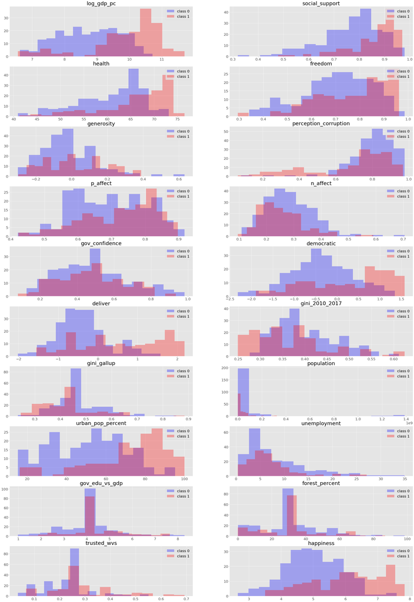

```python
labels = [0, 1]
colors = ['blue', 'red']

axes = plt.subplots(nrows=10, ncols=2, figsize=(40, 60))[1]
for i in range(len(data.columns)-1):
    ax = axes[(i-1)//2, (i-1) % 2]
    for label,color in zip(labels, colors):
        ax.hist(data.iloc[:,i][data["migration_class"]==label],
                label='class %s' % label,
                alpha=0.3,
                 color=color,
                 bins=15)
    ax.set_title(data.columns[i])
    ax.legend(loc="upper right")
plt.show()
```

The plots imply that the following features are potentially helpful to our classification task:

```python
features = [
    "log_gdp_pc",
    "social_support",
    "health",
    "freedom",
    "perception_corruption",
    "democratic",
    "deliver",
    "gini_2010_2017",
    "gini_gallup",
    "urban_pop_percent",
    "trusted_wvs",
    "happiness"
]
```

From here on, we use sklearn's `SelectKBest` API to generate the combination of best features using ANOVA F-value.

```python
data_X = data[features]
data_y = data["migration_class"]
kbest= [] # a list of tuples (Xs, used features)
for i in range(len(features)):
    best = SelectKBest(k = i + 1)
    kbest.append((best.fit_transform(data_X, data_y), [f for (f, v) in zip(features, best.get_support()) if v]))
```

### Building classifiers

We will build several classifiers using different algorithms: KNN, Decision Tree, and Naive Bayes. Then we can compare the three models and choose the best one based on the cross-validation scores.

**KNN**

KNN, among the three algorithms, involves the idea of distance and therefore we need to scale the data first:

```python
knn_Xs = zip([preprocessing.MinMaxScaler().fit_transform(f[0]) for f in kbest], [f[1] for f in kbest])
```

Now we build KNN models with various number of neighbors K, compare their score, and pick the best combination of features and K:

```
Using features deliver.
 Best score is acquired when K = 44, score is 0.747
Using features log_gdp_pc,deliver.
 Best score is acquired when K = 16, score is 0.760
Using features log_gdp_pc,deliver,happiness.
 Best score is acquired when K = 205, score is 0.773
Using features log_gdp_pc,deliver,urban_pop_percent,happiness.
 Best score is acquired when K = 93, score is 0.787
Using features log_gdp_pc,social_support,deliver,urban_pop_percent,happiness.
 Best score is acquired when K = 203, score is 0.787
Using features log_gdp_pc,social_support,health,deliver,urban_pop_percent,happiness.
 Best score is acquired when K = 192, score is 0.787
Using features log_gdp_pc,social_support,health,democratic,deliver,urban_pop_percent,happiness.
 Best score is acquired when K = 101, score is 0.787
Using features log_gdp_pc,social_support,health,perception_corruption,democratic,deliver,urban_pop_percent,happiness.
 Best score is acquired when K = 83, score is 0.787
Using features log_gdp_pc,social_support,health,perception_corruption,democratic,deliver,urban_pop_percent,trusted_wvs,happiness.
 Best score is acquired when K = 77, score is 0.773
Using features log_gdp_pc,social_support,health,perception_corruption,democratic,deliver,gini_2010_2017,urban_pop_percent,trusted_wvs,happiness.
 Best score is acquired when K = 41, score is 0.773
Using features log_gdp_pc,social_support,health,freedom,perception_corruption,democratic,deliver,gini_2010_2017,urban_pop_percent,trusted_wvs,happiness.
 Best score is acquired when K = 3, score is 0.800
Using features log_gdp_pc,social_support,health,freedom,perception_corruption,democratic,deliver,gini_2010_2017,gini_gallup,urban_pop_percent,trusted_wvs,happiness.
 Best score is acquired when K = 9, score is 0.800
```

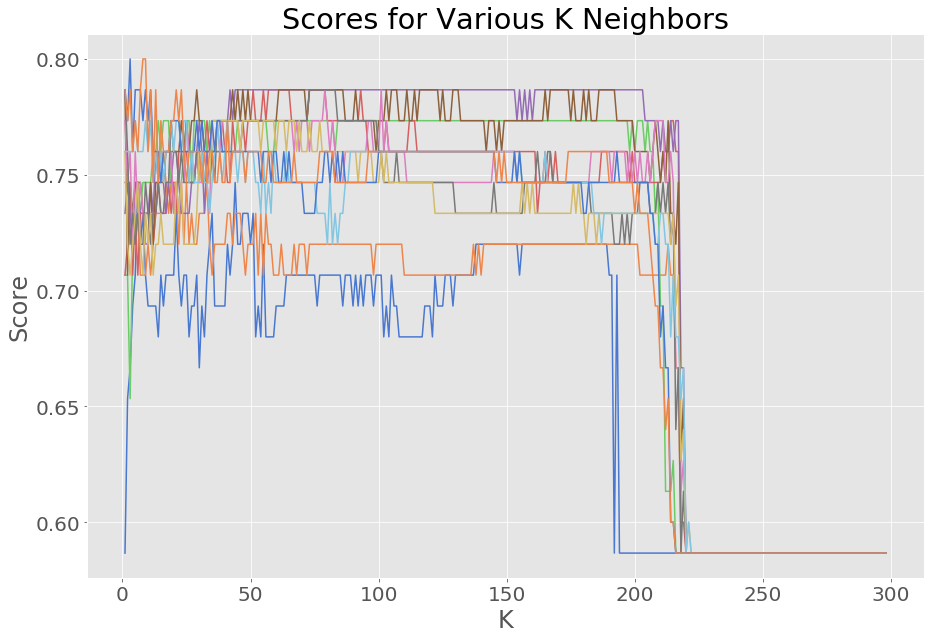

```python
for knn_X, fs in knn_Xs:
    X_train, X_test, y_train, y_test = train_test_split(knn_X, data_y, stratify=data_y, random_state=42, test_size=0.2)
    scores = []
    max_score = (None, 0)
    for k in range(1, len(X_train)-1):
        score = KNeighborsClassifier(n_neighbors=k, metric='euclidean').fit(X_train, y_train).score(X_test, y_test)
        scores.append(score)
        if score >= max_score[1]: # notice we update the max even when it's even, this is because we prefer bigger K to avoid capturing idiosyncrasies
            max_score = (k, score)
    print("Using features %s.\n Best score is acquired when K = %d, score is %.3f" % (str.join(",", fs), max_score[0], max_score[1]))
    #knn_model = KNeighborsClassifier(n_neighbors=max_score[0], metric='euclidean')
    sns.lineplot(y=scores,x=range(1, len(scores) + 1)).set(title="Scores for Various K Neighbors", xlabel="K",ylabel="Score" )
```

**Decision Tree**

Decision tree does not have distance involved, so scaling is not necessary. Like we need to to find the best number of neighbors for KNN, though, for decision tree model, we need to compare different the difference of max depths:

```
Using features deliver.
 Best score is acquired when depth is 3, score is 0.760
Using features log_gdp_pc,deliver.
 Best score is acquired when depth is 1, score is 0.760
Using features log_gdp_pc,deliver,happiness.
 Best score is acquired when depth is 1, score is 0.760
Using features log_gdp_pc,deliver,urban_pop_percent,happiness.
 Best score is acquired when depth is 1, score is 0.760
Using features log_gdp_pc,social_support,deliver,urban_pop_percent,happiness.
 Best score is acquired when depth is 1, score is 0.760
Using features log_gdp_pc,social_support,health,deliver,urban_pop_percent,happiness.
 Best score is acquired when depth is 1, score is 0.760
Using features log_gdp_pc,social_support,health,democratic,deliver,urban_pop_percent,happiness.
 Best score is acquired when depth is 1, score is 0.760
Using features log_gdp_pc,social_support,health,perception_corruption,democratic,deliver,urban_pop_percent,happiness.
 Best score is acquired when depth is 1, score is 0.760
Using features log_gdp_pc,social_support,health,perception_corruption,democratic,deliver,urban_pop_percent,trusted_wvs,happiness.
 Best score is acquired when depth is 1, score is 0.760
Using features log_gdp_pc,social_support,health,perception_corruption,democratic,deliver,gini_2010_2017,urban_pop_percent,trusted_wvs,happiness.
 Best score is acquired when depth is 8, score is 0.813
Using features log_gdp_pc,social_support,health,freedom,perception_corruption,democratic,deliver,gini_2010_2017,urban_pop_percent,trusted_wvs,happiness.
 Best score is acquired when depth is 5, score is 0.840
Using features log_gdp_pc,social_support,health,freedom,perception_corruption,democratic,deliver,gini_2010_2017,gini_gallup,urban_pop_percent,trusted_wvs,happiness.
 Best score is acquired when depth is 5, score is 0.813
```

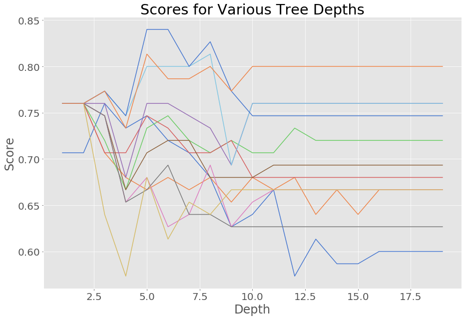

```python
for X, fs in kbest:
    X_train, X_test, y_train, y_test = train_test_split(X, data_y, stratify=data_y, random_state=42, test_size=0.2)
    scores = []
    max_score = (None, 0.0)
    for d in range(1, 20):
        score = DecisionTreeClassifier(max_depth=d, random_state=1).fit(X_train, y_train).score(X_test, y_test)
        scores.append(score)
        if (score > max_score[1]):
            max_score = (d, score)
    print("Using features %s.\n Best score is acquired when depth is %d, score is %.3f" % (str.join(",", fs), max_score[0], max_score[1]))
    sns.lineplot(y=scores,x=range(1, len(scores) + 1)).set(title="Scores for Various Tree Depths", xlabel="Depth",ylabel="Score" )
```

**Naive Bayes**

We will next build a Naive Bayes classifier. NB itself gives weights to the features accordingly, so feature scaling is not necessary here. It also does not need "parameters" like number of numbers in KNN and depth in tree. But we still want to compare the performance between different features combinations, while trying to keep the number of features reasonably low.

```
Using features log_gdp_pc,deliver,happiness.
 Best score is acquired, score is 0.747
```

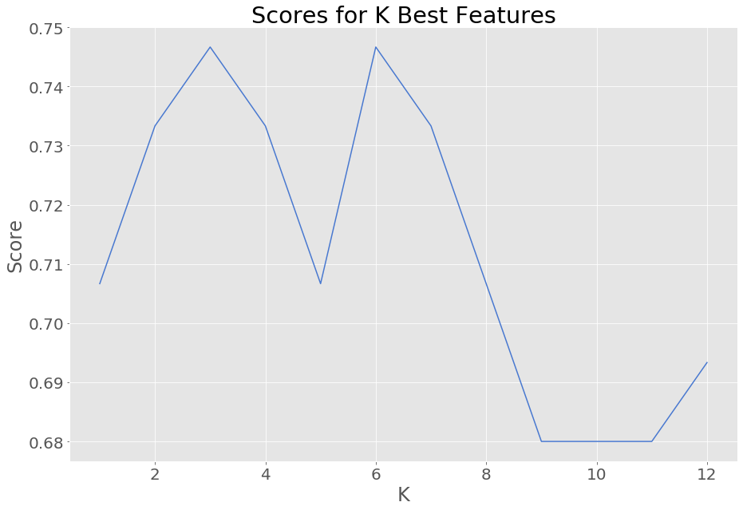

```python
scores=[]
max_score = (None, 0)
for X,fs in kbest:
    X_train, X_test, y_train, y_test = train_test_split(X, data_y, stratify=data_y, random_state=42, test_size=0.2)
    score = GaussianNB().fit(X_train, y_train).score(X_test, y_test)
    scores.append(score)
    if (score > max_score[1]):
        max_score = (str.join(",", fs), score)
print("Using features %s.\n Best score is acquired, score is %.3f" % max_score)
_=sns.lineplot(y=scores,x=range(1, len(scores)+1)).set(title="Scores for K Best Features", xlabel="K",ylabel="Score" )
```

Finally, we want to compare the three models and pick the best one using cross validation (10 fold, F1 scoring). The three candidate models we acquired above are:

- KNN Classifier with K = 9, using all features
- Decision Tree with depth = 5, using 11 features
- Naive Bayes with 3 features

```
        KNN  Decision Tree  Naive Bayes
0  0.714286       0.750000     0.666667
1  0.714286       0.538462     0.720000
2  0.740741       0.758621     0.685714
3  0.642857       0.866667     0.785714
4  0.666667       0.685714     0.787879
5  0.666667       0.666667     0.533333
6  0.666667       0.800000     0.800000
7  0.642857       0.636364     0.551724
8  0.714286       0.827586     0.800000
9  0.538462       0.666667     0.560000
```

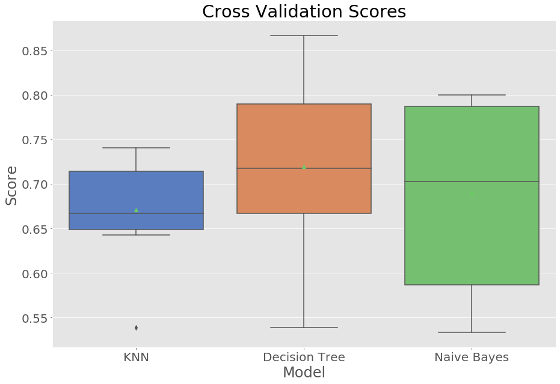

```python
from sklearn.model_selection import cross_val_score
knn_score = cross_val_score(KNeighborsClassifier(n_neighbors=9, metric='euclidean'), preprocessing.MinMaxScaler().fit_transform(kbest[-1][0]), data_y, cv=10, scoring="f1")
tree_score = cross_val_score(DecisionTreeClassifier(max_depth=5, random_state=1), kbest[-2][0], data_y, cv=10, scoring="f1")
nb_score = cross_val_score(GaussianNB(), kbest[2][0], data_y, cv=10, scoring="f1")
scores= pd.DataFrame({"KNN" : knn_score, "Decision Tree" : tree_score, "Naive Bayes" : nb_score})
print(scores)
_=sns.boxplot(x="variable", y="value", data=pd.melt(scores),showmeans=True).set(title="Cross Validation Scores", xlabel="Model", ylabel="Score")
```

Obviously, the decision tree classifier has the highest average cross-validation score. Yet it's worth noting that KNN has a shorter interquartile range and whiskers, implying it is more stable.

Lastly, we verify that our model outperforms the baseline score using stratified dummy classifier, so that we know our model is useful:

```
10 10
```

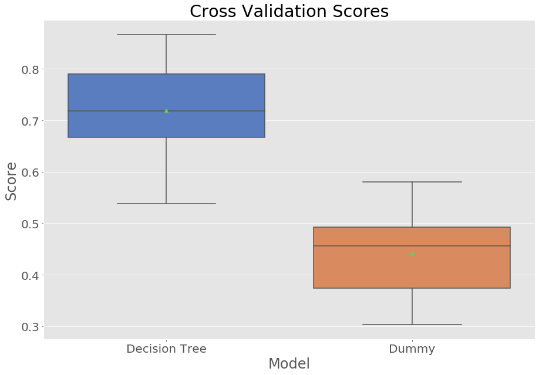

```python
from sklearn.dummy import DummyClassifier
baseline_scores = cross_val_score(DummyClassifier(strategy="stratified"), kbest[-2][0], data_y, cv=10, scoring="f1")
print(len(tree_score), len(baseline_scores))
scores = pd.DataFrame({"Decision Tree" : tree_score, "Dummy" : baseline_scores})
_=sns.boxplot(x="variable", y="value", data=pd.melt(scores),showmeans=True).set(title="Cross Validation Scores", xlabel="Model", ylabel="Score")
```

## TASK 3 – BUILD UNSUPERVISED LEARNING MODELS

Feature selection for unsupervised learning is beyond the scope of this course. One of the method is called [Principle Feature Analysis](http://venom.cs.utsa.edu/dmz/techrep/2007/CS-TR-2007-011.pdf). The code below is a implementation of PFA from [here](https://stats.stackexchange.com/questions/108743/methods-in-r-or-python-to-perform-feature-selection-in-unsupervised-learning).

```python
class PFA(object):
    def __init__(self, n_features, q=None):
        self.q = q
        self.n_features = n_features

    def fit(self, X):
        if not self.q:
            self.q = X.shape[1]

        sc = StandardScaler()
        X = sc.fit_transform(X)

        pca = PCA(n_components=self.q).fit(X)
        A_q = pca.components_.T

        kmeans = KMeans(n_clusters=self.n_features).fit(A_q)
        clusters = kmeans.predict(A_q)
        cluster_centers = kmeans.cluster_centers_

        dists = defaultdict(list)
        for i, c in enumerate(clusters):
            dist = euclidean_distances([A_q[i, :]], [cluster_centers[c, :]])[0][0]
            dists[c].append((i, dist))

        self.indices_ = [sorted(f, key=lambda x: x[1])[0][0] for f in dists.values()]
        self.features_ = X[:, self.indices_]
```

We use PFA to reduce our features to 3: log GDP per capita, social support, and freedom to make life choice.

```python
pfa = PFA(n_features=3)
pfa.fit(data_X)

cluster_X = data_X.iloc[:, pfa.indices_]
cluster_X
```

|  | log_gdp_pc | social_support | freedom |
| --- | --- | --- | --- |
| 4 | 7.480296 | 0.520637 | 0.530935 |
| 9 | 7.472197 | 0.490880 | 0.427011 |
| 11 | 9.042030 | 0.821372 | 0.528605 |
| 15 | 9.246630 | 0.784502 | 0.601512 |
| 20 | 9.376133 | 0.637698 | 0.749611 |
| ... | ... | ... | ... |
| 1627 | 8.179307 | 0.780023 | 0.787760 |
| 1632 | 8.220852 | 0.743754 | 0.823169 |
| 1635 | 7.500967 | 0.828113 | 0.455957 |
| 1640 | 7.818771 | 0.896476 | 0.469531 |
| 1645 | 7.851042 | 0.754147 | 0.752826 |

375 rows × 3 columns

Next, we scale the data:

```python
scaled_cluster_X = preprocessing.MinMaxScaler().fit_transform(cluster_X)
```

Finally, we try out a number of K value and find the one that minimize within-cluster sum of squares, while also keeping a reasonably low K:

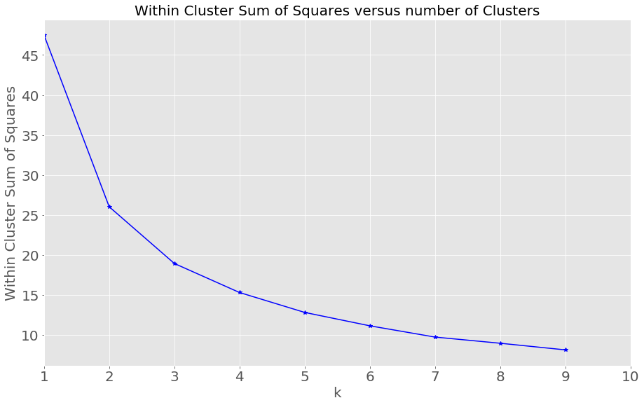

```python
k_rng = range(1,10)
est = [KMeans(n_clusters = k).fit(scaled_cluster_X) for k in k_rng]

# Generally want to minimize WSS, while also minimizing k
within_cluster_sum_squares = [e.inertia_ for e in est]
fig, axes = plt.subplots()
fig.set_size_inches(15,20)
# Plot the results
plt.subplot(212)
plt.plot(k_rng, within_cluster_sum_squares, 'b*-')
plt.xlim([1,10])
plt.grid(True)
plt.xlabel('k', fontsize=20)
plt.ylabel('Within Cluster Sum of Squares', fontsize=20)
plt.title('Within Cluster Sum of Squares versus number of Clusters', fontsize=20)
```

```python
kmeans = KMeans(n_clusters =3).fit(scaled_cluster_X)
predicted_clusters = kmeans.predict(scaled_cluster_X)
centers = kmeans.cluster_centers_
```

Now we visualize the data:

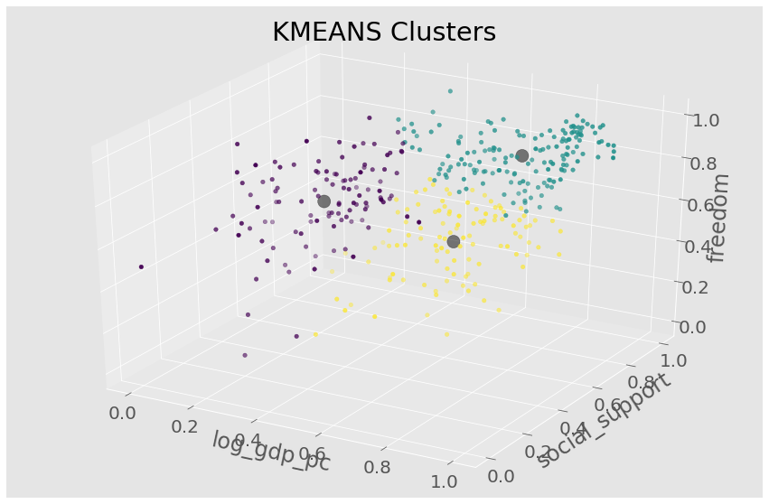

```python
fig = plt.figure()
ax = fig.add_subplot(111, projection='3d')
ax.scatter(scaled_cluster_X[:,0], scaled_cluster_X[:,1], scaled_cluster_X[:,2], c=predicted_clusters, marker='o')
ax.scatter(centers[:,0], centers[:,1], centers[:,2], c='black', marker='o', s=200, alpha=0.5)
ax.set_xlabel(cluster_X.columns[0])
ax.set_ylabel(cluster_X.columns[1])
ax.set_zlabel(cluster_X.columns[2])
ax.set_title("KMEANS Clusters")
plt.show()
```

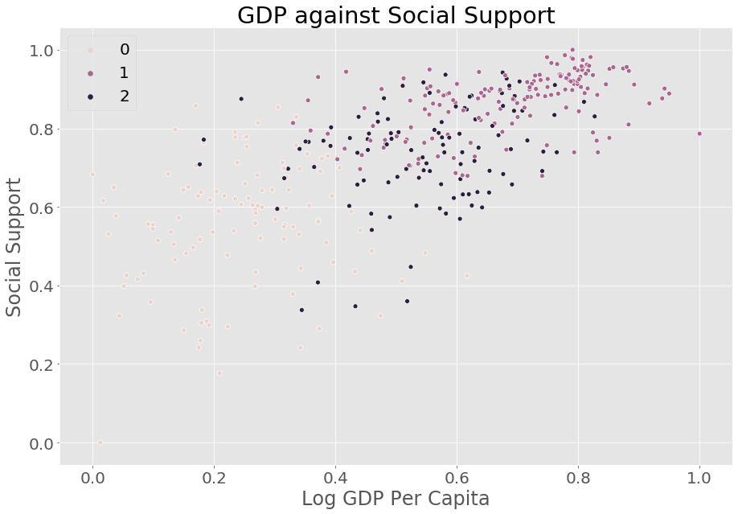

```python
_=sns.scatterplot(x=scaled_cluster_X[:,0], y = scaled_cluster_X[:,1],hue=predicted_clusters).set(title="GDP against Social Support", xlabel="Log GDP Per Capita", ylabel="Social Support")
```

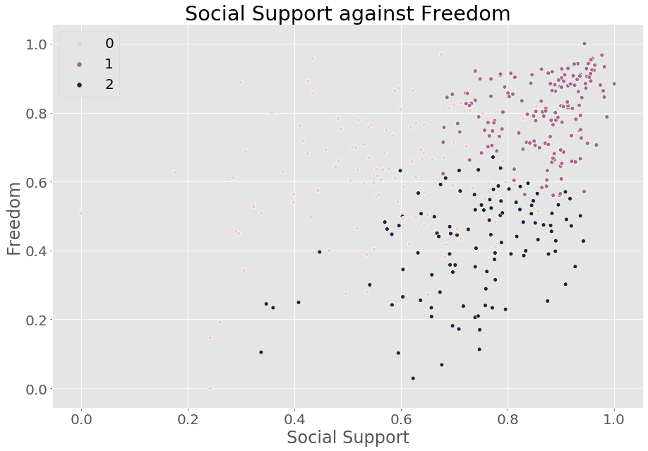

```python
_=sns.scatterplot(x=scaled_cluster_X[:,1], y = scaled_cluster_X[:,2],hue=predicted_clusters).set(title="Social Support against Freedom", xlabel="Social Support", ylabel="Freedom")
```

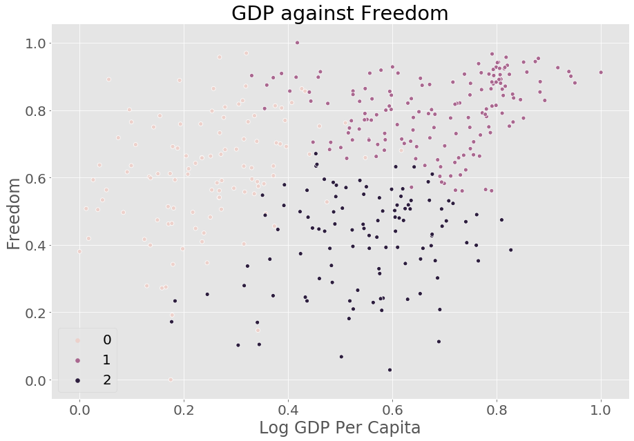

```python
_=sns.scatterplot(x=scaled_cluster_X[:,0], y = scaled_cluster_X[:,2],hue=predicted_clusters).set(title="GDP against Freedom", xlabel="Log GDP Per Capita", ylabel="Freedom")
```

## Task 4

### Introduction

In this assignment, we have done some further investigation on the WHR data. In particular, we have focused on:

- Build a model that predict if a country has positive or negative migration
- Build a model that divide data into some clusters and see if there's some interesting fact revealed

The data sources we use are the cleaned WHR data from previous assignment, as well as the Net Migration indicator data from World Bank.

### Process

To build the model to predict net migration, we first need some labeled data, as this is a supervised learning problem. Such data is fetched from World Bank API and integrated into our WHR data in a similar manner to the previous assignment (handling country name variant, etc.)

Then we explore what features may be useful in predicting the migration class, and use these features as candidate to algorithmically select best features from. From here on, we tried the combination of features and different classification algorithms: KNN, decision tree, and naive Bayes. For KNN, we also try to find the optimal number of neighbors, and for decision tree, we also try to find the optimal tree depth.

After comparing all kinds of combinations, we eventually pick decision tree with max depth 5 as our classifier to predict if a country has positive or negative migration. Our classifier outperforms by much the base line dummy classifier.

Next we use KMeans algorithm to divide our data into clusters. We use PFA to pick three principle features (log GDP per capita, social support, freedom) and then build the model based on them. After comparing the WSS against K, we pick k = 3 for the result model.

### Conclusion

To predict if a country has positive or negative migration, we use the following features: Log GDP per capita, social support, expected health life, freedom to make life choice, perception of corruption, democratic quality , service deliver quality, Gini from 2010 to 2017, urban population percentage, trust Score by WVS, and subjective happiness score, to build a decision tree model with max depth 5. The model has reached roughly 0.72 F1 score in cross-validation.

For clustering, we have used log GDP per capita, social support, freedom to build a KMeans model, with K = 3. The result clusters are intertwined and probably not very meaningful, but we can still observe some interesting facts from it. Specifically, we observe that the data of developed countries are distributed in higher density, implying they have a similar performance in each aspect.